# Supplemental Materials

### 3.2.3 Compositional RDA plots

#### Explained Variance in RDA’s

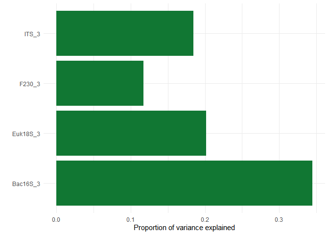

Figure 3.10: Proportion of variance explained by microtopography. Model names are described as the targeted gene (16S, 18S, ITS, or, F230), summarization level (ESV, genus, or functional groupings) and the soil layers represented in the rda model (MIN = 0-10 cm depth mineral soil samples, LFH = L, FH, or LFH samples).

#### Bacterial (16S)

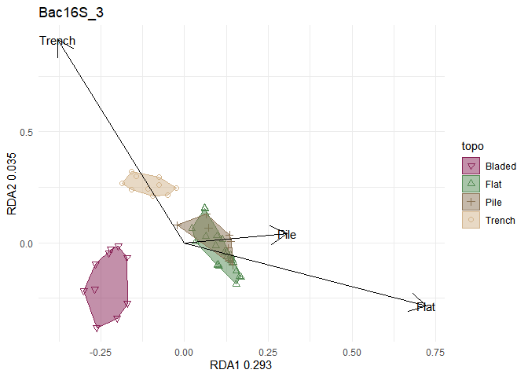

#### Fungal (ITS)

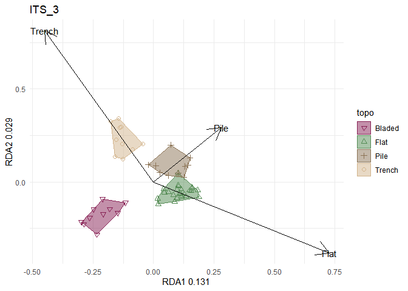

#### Arthropods (F230)

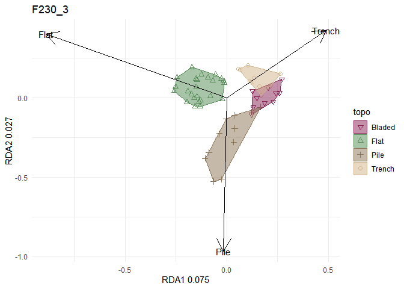

#### Eukaryotes (18S)

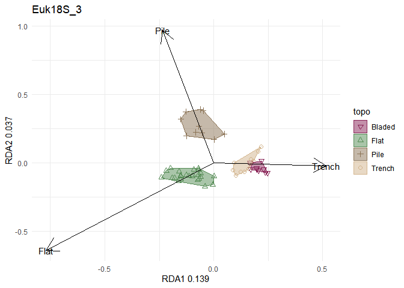

### 3.2.4 Differences in specific organisms

#### Bac16S

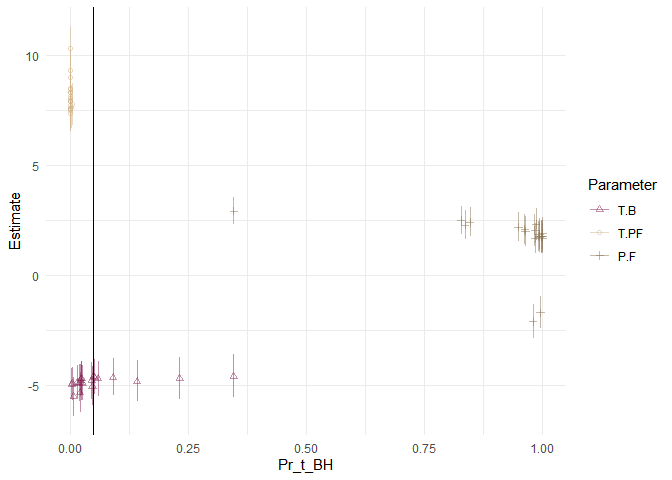

Graph shows 20 most significant organisms for each parameter.

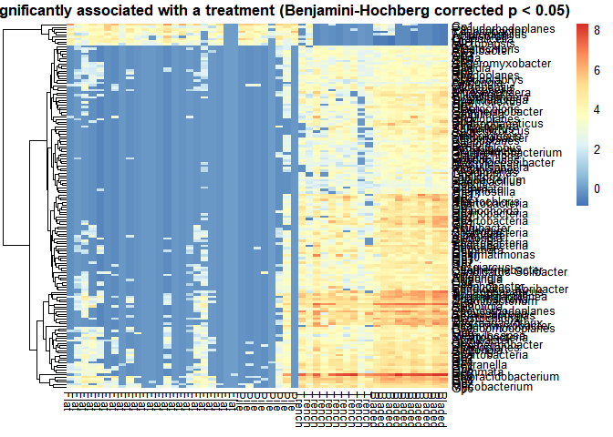

#### ITS

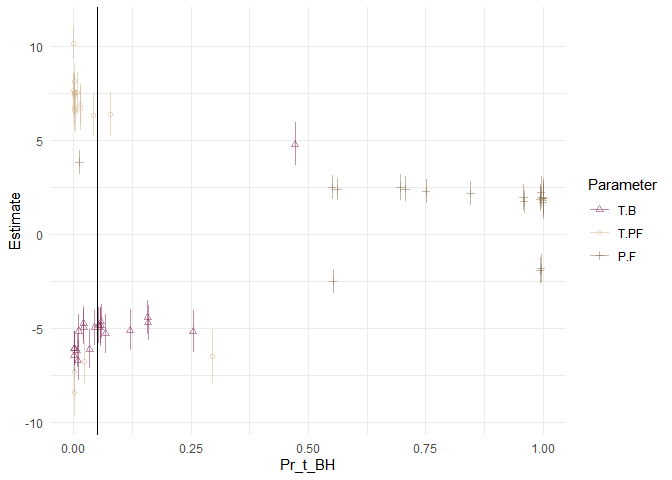

Graph shows 20 most significant organisms for each parameter.

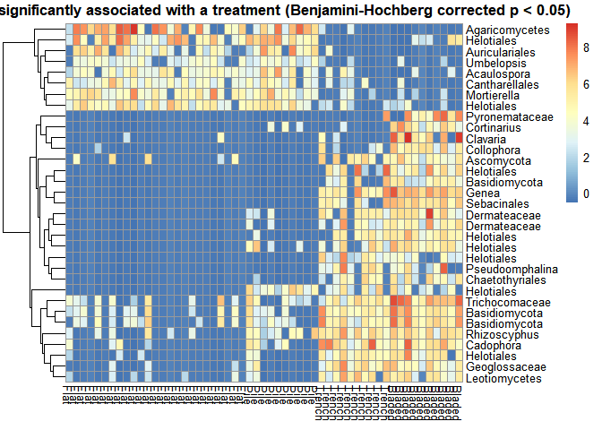

#### F230

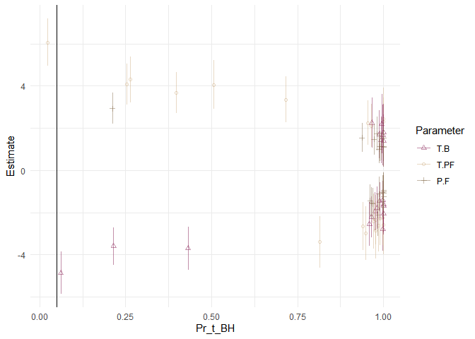

Graph shows 20 most significant organisms for each parameter.

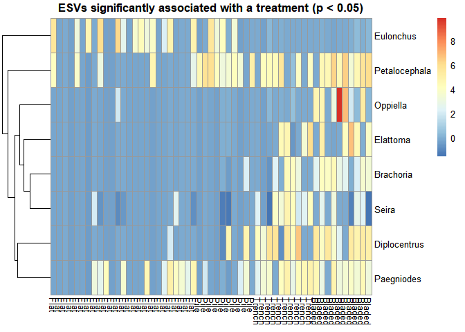

#### Euk18S

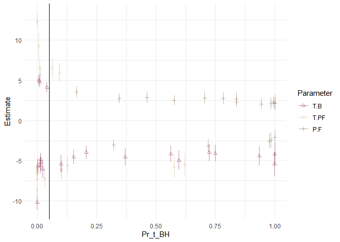

Graph shows 20 most significant organisms for each parameter.

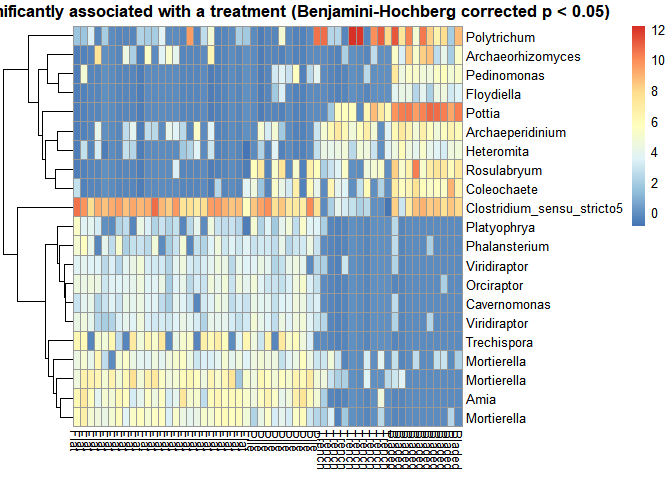

Table 3.2: Taxonomic information for ESVs identified as significantly different amongst topographic features.

| dataset | Domain | Kingdom | Phylum | Class | Order | Family | Genus | Species |
| --- | --- | --- | --- | --- | --- | --- | --- | --- |
| Bac16S_3 | Bacteria | NA | Acidobacteria | Acidobacteria_Gp1 | Gp1 | Gp1 | Gp1 | NA |
| Bac16S_3 | Bacteria | NA | Acidobacteria | Acidobacteria_Gp2 | Gp2 | Gp2 | Gp2 | NA |
| Bac16S_3 | Bacteria | NA | Proteobacteria | Alphaproteobacteria | Micropepsales | Micropepsaceae | Micropepsis | NA |
| Bac16S_3 | Bacteria | NA | Verrucomicrobia | Spartobacteria | Spartobacteria_genera_incertae_sedis | Spartobacteria_genera_incertae_sedis | Spartobacteria_genera_incertae_sedis | NA |
| Bac16S_3 | Bacteria | NA | Proteobacteria | Alphaproteobacteria | Rhizobiales | Blastochloridaceae | Blastochloris | NA |
| Bac16S_3 | Archaea | NA | Thaumarchaeota | Nitrososphaerales | Nitrososphaerales | Nitrososphaeraceae | Nitrososphaera | NA |
| Bac16S_3 | Bacteria | NA | Proteobacteria | Alphaproteobacteria | Rhizobiales | Bradyrhizobiaceae | Pseudorhodoplanes | NA |
| Bac16S_3 | Bacteria | NA | Acidobacteria | Acidobacteria_Gp1 | Granulicella | Granulicella | Granulicella | NA |
| Bac16S_3 | Bacteria | NA | Planctomycetes | Planctomycetacia | Planctomycetales | Gemmataceae | Fimbriiglobus | NA |
| Bac16S_3 | Bacteria | NA | Acidobacteria | Acidobacteria_Gp4 | Gp4 | Gp4 | Gp4 | NA |
| Bac16S_3 | Bacteria | NA | Planctomycetes | Planctomycetacia | Planctomycetales | Gemmataceae | Gemmata | NA |
| Bac16S_3 | Bacteria | NA | Proteobacteria | Alphaproteobacteria | Rhizobiales | Bradyrhizobiaceae | Afipia | NA |
| Bac16S_3 | Bacteria | NA | Proteobacteria | Alphaproteobacteria | Rhizobiales | Bradyrhizobiaceae | Pseudolabrys | NA |
| Bac16S_3 | Bacteria | NA | Proteobacteria | Alphaproteobacteria | Rhodospirillales | Reyranellaceae | Reyranella | NA |
| Bac16S_3 | Bacteria | NA | Firmicutes | Limnochordia | Limnochordales | Limnochordaceae | Limnochorda | NA |
| Bac16S_3 | Bacteria | NA | Acidobacteria | Acidobacteria_Gp6 | Gp6 | Gp6 | Gp6 | NA |
| Bac16S_3 | Bacteria | NA | Proteobacteria | Alphaproteobacteria | Rhizobiales | Kaistiaceae | Bauldia | NA |
| Bac16S_3 | Bacteria | NA | Acidobacteria | Acidobacteria_Gp3 | Gp3 | Gp3 | Gp3 | NA |
| Bac16S_3 | Bacteria | NA | Proteobacteria | Gammaproteobacteria | Gammaproteobacteria_incertae_sedis | Acidibacter | Acidibacter | NA |
| Bac16S_3 | Bacteria | NA | Proteobacteria | Alphaproteobacteria | Rhizobiales | Bradyrhizobiaceae | Rhodoplanes | NA |
| Bac16S_3 | Bacteria | NA | Acidobacteria | Acidobacteria_Gp1 | Edaphobacter | Edaphobacter | Edaphobacter | NA |
| Bac16S_3 | Bacteria | NA | Proteobacteria | Alphaproteobacteria | Rhodospirillales | Rhodospirillaceae | Aliidongia | NA |
| Bac16S_3 | Bacteria | NA | Proteobacteria | Betaproteobacteria | Nitrosomonadales | Sterolibacteriaceae | Sterolibacterium | NA |
| Bac16S_3 | Bacteria | NA | Proteobacteria | Deltaproteobacteria | Myxococcales | Myxococcaceae | Aggregicoccus | NA |
| Bac16S_3 | Bacteria | NA | Acidobacteria | Acidobacteria_Gp7 | Gp7 | Gp7 | Gp7 | NA |
| Bac16S_3 | Bacteria | NA | Proteobacteria | Deltaproteobacteria | Desulfuromonadales | Geobacteraceae | Geothermobacter | NA |
| Bac16S_3 | Bacteria | NA | Proteobacteria | Alphaproteobacteria | Rhizobiales | Bradyrhizobiaceae | Nitrobacter | NA |
| Bac16S_3 | Bacteria | NA | Cyanobacteria/Chloroplast | Chloroplast | Chloroplast | Chloroplast | Streptophyta | NA |
| Bac16S_3 | Bacteria | NA | Acidobacteria | Acidobacteria_Gp1 | Terracidiphilus | Terracidiphilus | Terracidiphilus | NA |
| Bac16S_3 | Bacteria | NA | Chloroflexi | Anaerolineae | Anaerolineales | Anaerolineaceae | Longilinea | NA |

[output cut: 85 more lines]

## 3.3 Seasonal Patterns

### 3.3.1 Differences in diversity

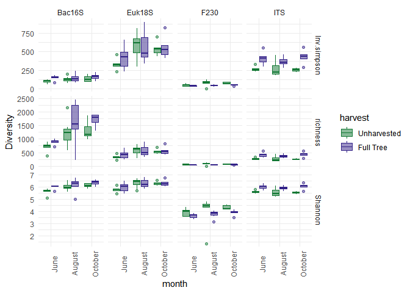

There were seasonal changes in the different metabarcode communities that were mostly consistent in full-tree and unharvested treatments. Eukaryotic (18S) diversity metrics were generally elevated in the month of August. Bacterial diversity increased as the season progressed from June through to October. In contrast, arthropod and fungal diversity were generally stable through the months sampled. However, tree removal did result in a relatively stable eukaryotic (18S) community Simpson’s diversity across the seasonal sampling periods, compared with an elevated diversity metric in the uncut forest in August (Fig 3.11).

### 3.3.2 Compositional PCA plots

#### Bacterial (16S)

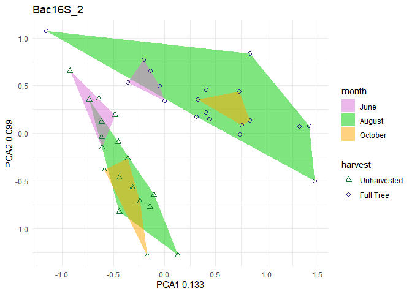

#### Fungal (ITS)

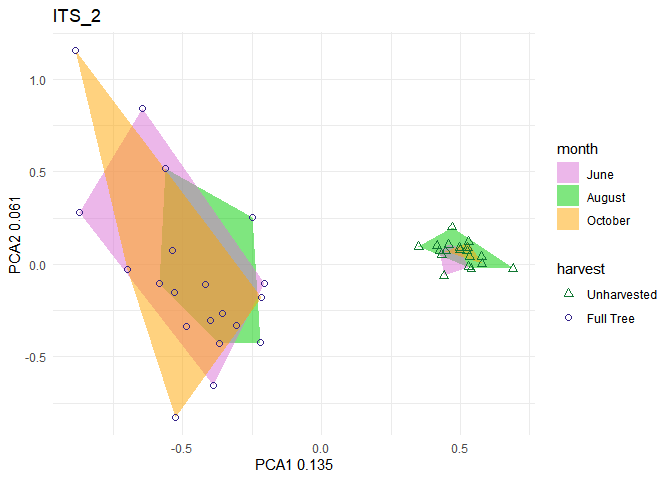

#### Arthropods (F230)

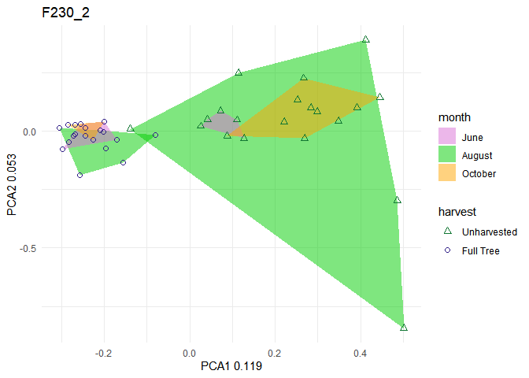